# R Project

Ria

2023-12-19

### **What are the key demographics of visitors in London?**

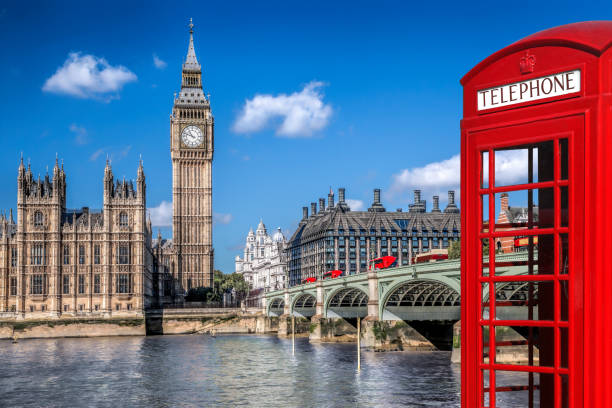

### This is a sneak peek of the datasets being used:

```
##       year        quarter             market            dur_stay
##  Min.   :2002   Length:61462       Length:61462       Length:61462
##  1st Qu.:2006   Class :character   Class :character   Class :character
##  Median :2011   Mode  :character   Mode  :character   Mode  :character
##  Mean   :2011
##  3rd Qu.:2015
##  Max.   :2020
##      mode             purpose              visits          expenditure
##  Length:61462       Length:61462       Min.   :     0.1   Min.   :        0
##  Class :character   Class :character   1st Qu.:   822.9   1st Qu.:   321693
##  Mode  :character   Mode  :character   Median :  1797.3   Median :  1047351
##                                        Mean   :  4927.6   Mean   :  3086634
##                                        3rd Qu.:  4416.6   3rd Qu.:  3007542
##                                        Max.   :187487.3   Max.   :373232590
##      nights              sample
##  Min.   :      0.3   Min.   :  1.000
##  1st Qu.:   3901.6   1st Qu.:  1.000
##  Median :  10676.9   Median :  2.000
##  Mean   :  30300.9   Mean   :  6.099
##  3rd Qu.:  29483.0   3rd Qu.:  5.000
##  Max.   :2492178.5   Max.   :299.000
```

```
## # A tibble: 6 × 10
##    year quarter   market dur_stay mode  purpose visits expenditure nights sample
##   <dbl> <chr>     <chr>  <chr>    <chr> <chr>    <dbl>       <dbl>  <dbl>  <dbl>
## 1  2002 January-… Belgi… 1-3  ni… Air   Holiday  3572.     969138.  6954.      5
## 2  2002 January-… Belgi… 1-3  ni… Air   Busine…  9284.    2399577. 12605.     19
## 3  2002 January-… Belgi… 1-3  ni… Air   Visiti…   877.      89833.  2153.      3
## 4  2002 January-… Belgi… 1-3  ni… Air   Miscel…   164.      10160.   164.      1
## 5  2002 January-… Belgi… 1-3  ni… Sea   Busine…  1649.      16789.  1650.      1
## 6  2002 January-… Belgi… 1-3  ni… Sea   Miscel…   591.       3952.  1772.      1
```

```
## # A tibble: 6 × 10
##    year quarter   market dur_stay mode  purpose visits expenditure nights sample
##   <dbl> <chr>     <chr>  <chr>    <chr> <chr>    <dbl>       <dbl>  <dbl>  <dbl>
## 1  2020 January-… Other… 4-7  ni… Air   Visiti…  4823.    4259258. 6.67e4      6
## 2  2020 January-… Other… 4-7  ni… Air   Miscel…  1695.    1103167. 8.83e3      2
## 3  2020 January-… Other… 8-14 ni… Air   Holiday  1487.    2022254. 7.84e3      1
## 4  2020 January-… Other… 8-14 ni… Air   Visiti…  2417.    1847152. 6.39e4      2
## 5  2020 January-… Other… 15+  ni… Air   Holiday  2473.    1006109. 3.51e4      2
## 6  2020 January-… Other… 15+  ni… Air   Visiti…  4124.    3960705. 1.35e5      4
```

### What purpose do people usually visit London for?

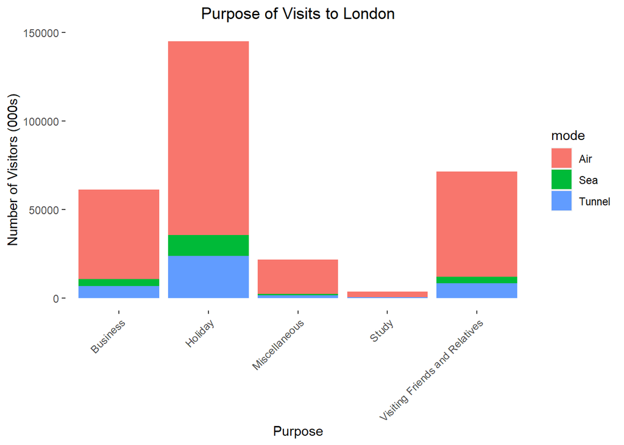

- We can see here the main purpose of visiting London is holiday, and the least number of visits come from students for the purpose of study. It seems that for each purpose the main mode of transport into London is via air.

### What is the porportion of visitors using the different modes of transportation to get into London?

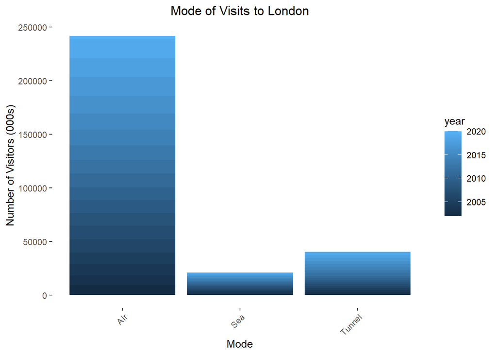

- It can be observed that the main mode of traveling to London is through air travel. This might be due to the fact that most of the visitors are international, and the most convenient way of getting into London is by airplane, and London has is a major city with two international airports. Travel by sea and by Tunnel would make sense from nearby countries which have a route via sea or tunnel, and even then they might prefer to travel by air as it is faster and more convenient.

### How did the number of visitors change over the years?

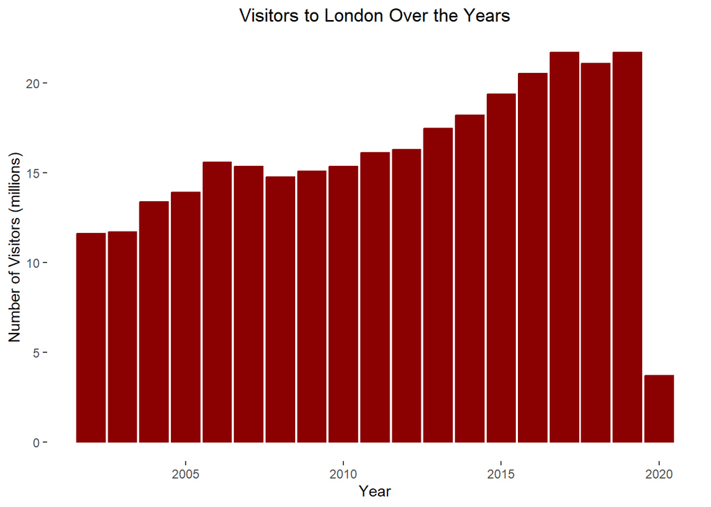

- There is generally an increasing trend of visitors to London over the years. This might be due to increased connectivity and transportation systems. There is a large dip in 2020, this is most probably due to Covid restrictions.

### How modes of travel change over the years?

Percentage of Visitors Traveling to London by Different Modes over the Years

| year | total_visitors | air_percentage | sea_percentage | tunnel_percentage |
| --- | --- | --- | --- | --- |
| 2002 | 11603382 | 79.19 | 8.98 | 11.82 |
| 2003 | 11695750 | 78.08 | 8.98 | 12.94 |
| 2004 | 13389330 | 77.80 | 9.45 | 12.74 |
| 2005 | 13892569 | 78.77 | 8.23 | 13.00 |
| 2006 | 15592646 | 79.84 | 8.30 | 11.86 |
| 2007 | 15339771 | 81.79 | 7.02 | 11.20 |
| 2008 | 14752994 | 80.69 | 7.93 | 11.38 |
| 2009 | 15092329 | 79.73 | 7.66 | 12.61 |
| 2010 | 15353011 | 78.06 | 7.46 | 14.47 |
| 2011 | 16102676 | 78.65 | 7.63 | 13.72 |
| 2012 | 16279300 | 78.14 | 6.63 | 15.23 |
| 2013 | 17473810 | 78.35 | 6.98 | 14.67 |
| 2014 | 18188887 | 78.51 | 6.35 | 15.15 |
| 2015 | 19384746 | 78.39 | 6.40 | 15.21 |
| 2016 | 20532679 | 80.26 | 5.86 | 13.88 |
| 2017 | 21707639 | 81.89 | 4.94 | 13.17 |
| 2018 | 21072027 | 82.12 | 4.86 | 13.02 |
| 2019 | 21713465 | 82.67 | 4.84 | 12.49 |
| 2020 | 3696257 | 81.85 | 4.54 | 13.61 |

- This table shows the proportions of people taking the different modes of transportation into London remained fairly the same throughout the years.

### What is the mean number of visitors from the different countries?

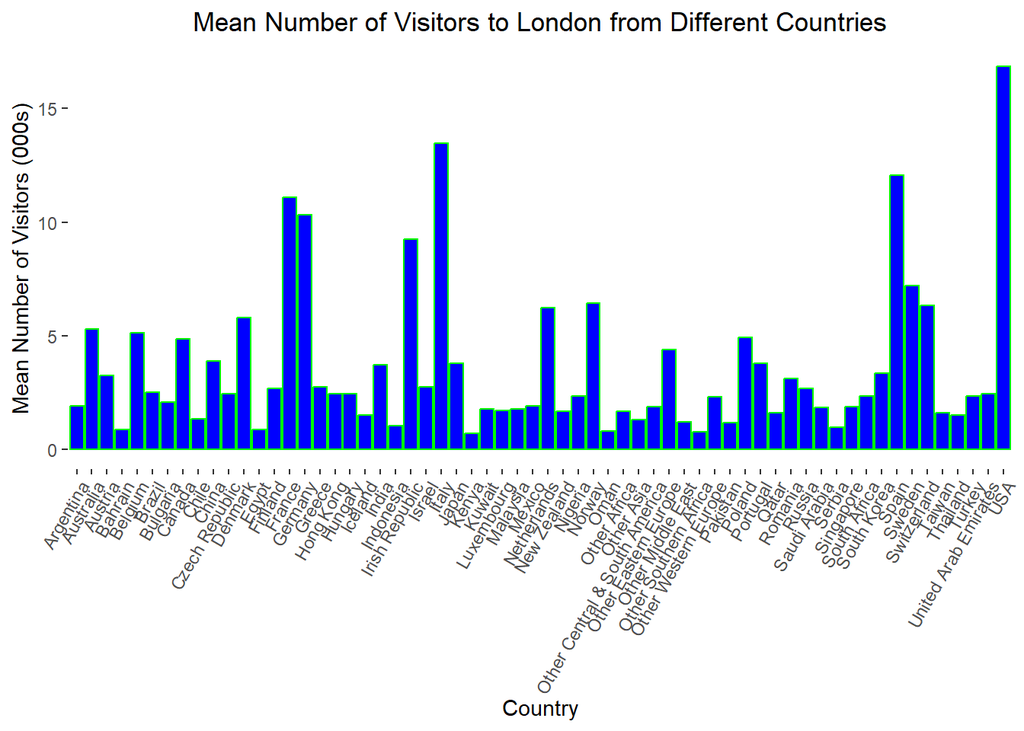

### People from which country spend the most amount of money averagely per pax in 2020?

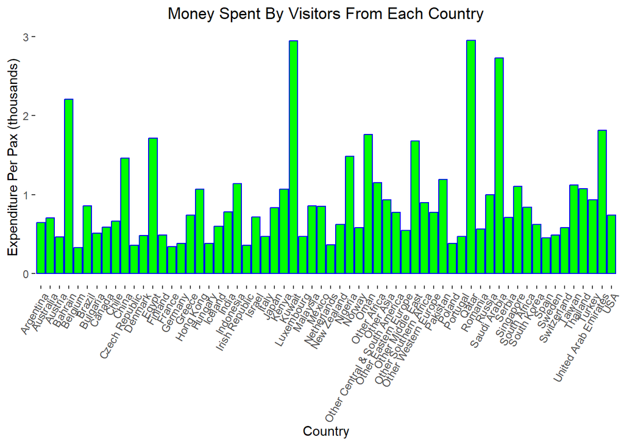

- We can see that visitors from Bahrain, Kuwait, Qatar, Saudi Arabia and United Arab Emirates tend to spend most amount of money per pax in London. This is rather interesting, as all of them are countries of the Middle East.

### Which quarter of the year do we see the most visitors?

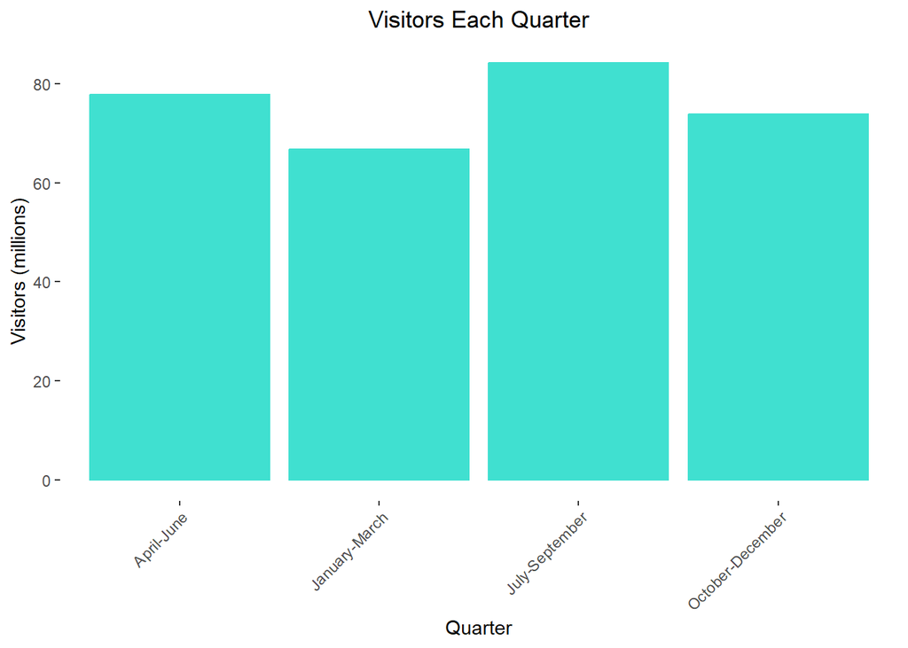

- July-September seems to be the most popular time for visiting London, I suspect it is due to the weather being the best during this period as it is summer. However, there is not much significant difference between the quarters.  
  This report shows the visitor demographics of London. Effective visualisations used will show the different demographics of the visitors. The data has been reshaped and cleaned using dplyr and tidyr to make it suitable for each visualisation. There were challenges in trying to figure out how to reshape the data in order to get the most effective visualisation in what I was trying to show. I also calculated some mean and percentages to show in the visualisations. This project could be extended further by including other datasets and finding more advanced statistical analysis, and doing correlation analyses between different factors.